# PD4

Marta Jóźwik

3 listopada 2016

Tym razem znalazłam w gazecie Wyborczej z 2 listopada na str. 10 artykuł o planowanej akcyzie na samochody w 2017 roku, dane zostały tam przedstawione w postaci tabeli, z której niwiele można było zauważyć, oprócz oczywiście planowanych stawek. Moim pomysłem było przedstawieni ich w sposob. który pozwala porównać poszczególne akcyzy wizualnie (wysokością kropek) w zależności od pojemności (na osi x) i roku produkcji (uznałam, że poniewż są tylko 4 poziomy tych wartości przedstawienie ich prze kolor będzie najlepsze). Nie chciałam jednak usuwać zupełnie danych o konkretnych stawkach (kogoś może interesować konkretna stawka przewidziana dla jego samochodu), dlatego zamieściłam na wykresie również wartości. Sądzę, że teraz lepiej widać jakie sa przeliczniki pomiędzy różnymi typami pojemności/roku produkcji i dodałam też linie średniej akcyzy wyliczone dla 4 poziomów roku produkcji, żeby móc od razu wizualnie porównać jak konkretne stawki się od niej różnią. Sądzę że przedstawione w ten sposób dane są czytelne zarówno dla kogoś, kogo interesuje tylko 1 konkretna wartość do odczytania, jak i dla kogoś kto chciałby mieć wizualne porównanie między poszczególnymi stawkami. Rozważałam też podzielenie danych na 4 podgrupy w zależności od roku, jednak ponieważ wszystko umieściłam na jednym wykresie można bez problemu porównywać zarówno akcyzy w róznych latach produkcji jak i przy różnych pojemnościach.

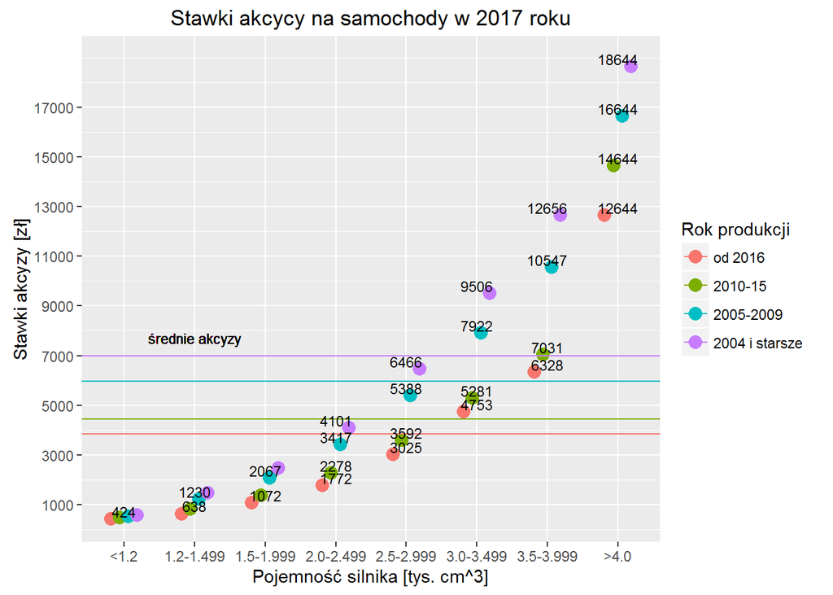